# Tarea1: Gapminder

Alejandro Nivón Ruiz 109649

20 de agosto de 2018

Tarea. Explora la base de datos gapminder, estos datos están incluidos en el paquete del mismo nombre, para acceder a ellos basta con cargar el paquete.

realiza al menos 3 gráficas y explica las relaciones que encuentres. Debes usar lo que revisamos en estas notas: al menos una de las gráficas debe ser de páneles, realiza una gráfica con datos de México, y (opcional)si lo consideras interesante, puedes crear una variable categórica utilizando la función cut2 del paquete Hmisc.

## Excerpt of the Gapminder data on life expectancy, GDP per capita, and population by country

```r
gapminder %>% head()
```

```
## # A tibble: 6 x 6
##   country     continent  year lifeExp      pop gdpPercap
##   <fct>       <fct>     <int>   <dbl>    <int>     <dbl>
## 1 Afghanistan Asia       1952    28.8  8425333      779.
## 2 Afghanistan Asia       1957    30.3  9240934      821.
## 3 Afghanistan Asia       1962    32.0 10267083      853.
## 4 Afghanistan Asia       1967    34.0 11537966      836.
## 5 Afghanistan Asia       1972    36.1 13079460      740.
## 6 Afghanistan Asia       1977    38.4 14880372      786.
```

```r
gapminder %>% summary()
```

```
##         country        continent        year         lifeExp
##  Afghanistan:  12   Africa  :624   Min.   :1952   Min.   :23.60
##  Albania    :  12   Americas:300   1st Qu.:1966   1st Qu.:48.20
##  Algeria    :  12   Asia    :396   Median :1980   Median :60.71
##  Angola     :  12   Europe  :360   Mean   :1980   Mean   :59.47
##  Argentina  :  12   Oceania : 24   3rd Qu.:1993   3rd Qu.:70.85
##  Australia  :  12                  Max.   :2007   Max.   :82.60
##  (Other)    :1632
##       pop              gdpPercap
##  Min.   :6.001e+04   Min.   :   241.2
##  1st Qu.:2.794e+06   1st Qu.:  1202.1
##  Median :7.024e+06   Median :  3531.8
##  Mean   :2.960e+07   Mean   :  7215.3
##  3rd Qu.:1.959e+07   3rd Qu.:  9325.5
##  Max.   :1.319e+09   Max.   :113523.1
##
```

## Algunas gráficas explorando Datos

Primero se comparará la evolución de la esperanza de vida promedio por continente a través del tiempo.

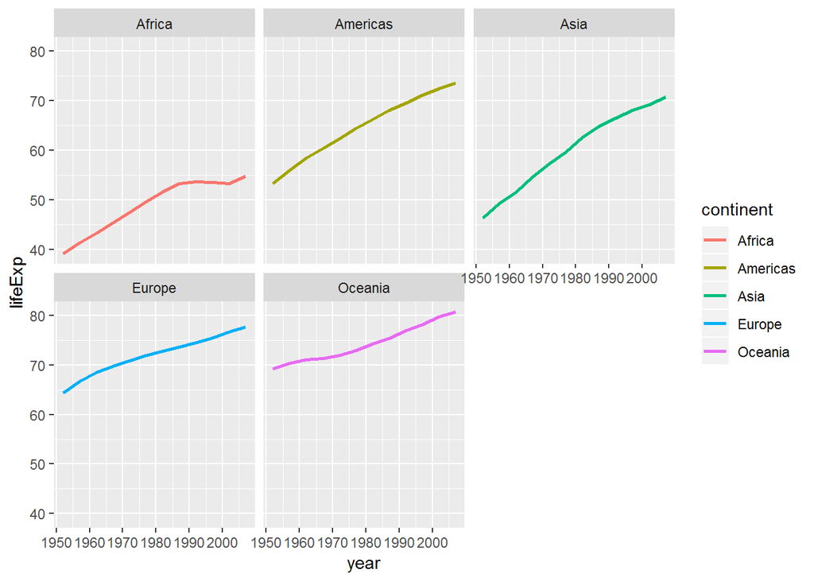

```r
cont <- gapminder %>% select(c(continent, year, lifeExp)) %>%  group_by(continent, year)%>%
  summarise(lifeExp = mean(lifeExp))

ggplot(cont, aes(x = year, y = lifeExp, colour = continent)) + facet_wrap(~ continent) +
  geom_line(size=1)
```

Para el caso de México se puede comparar la evolución versus todo el continente:

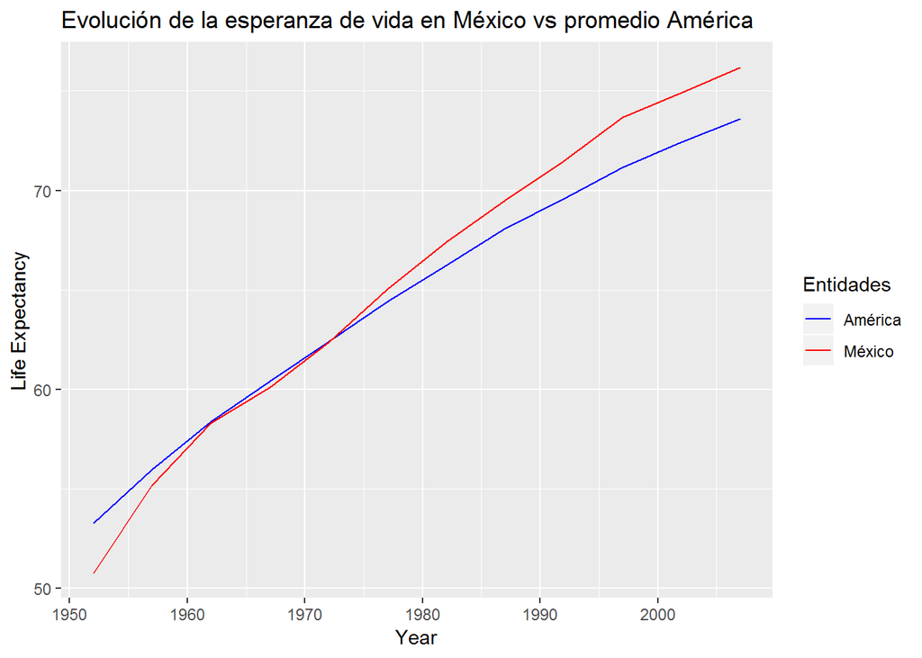

```r
America <- cont %>% filter(continent == 'Americas')
Mexico <- gapminder %>% select(c(country, year, lifeExp)) %>% filter(country == 'Mexico')

ggplot() + ggtitle('Evolución de la esperanza de vida en México vs promedio América') +
  labs(x = "Year",  y='Life Expectancy') +
  geom_line(aes(x=America$year, y=America$lifeExp, color='América'), show.legend = TRUE) +
  geom_line(aes(x=Mexico$year, y=Mexico$lifeExp, color='México'), show.legend = TRUE) +
  scale_color_manual('Entidades', values = c('blue', 'red'))
```

Aquí podemos ver que cerca de 1975 México superó el promedio de expectativa de vida en América.

Una cuestión interesante para México sería la de ver la relación entre la expectativa de vida y la población.

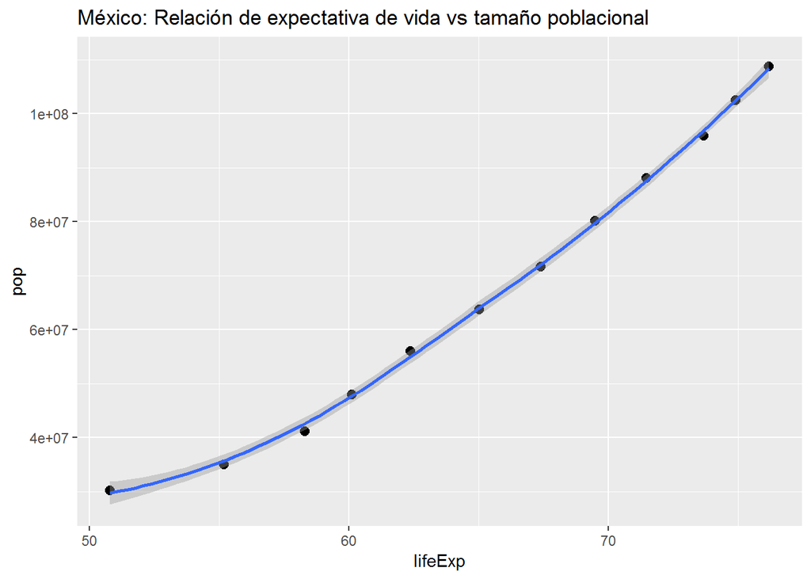

```r
Mexico <- gapminder %>% select(c(country, year, lifeExp, pop)) %>% filter(country == 'Mexico')

ggplot(Mexico) + geom_point(aes(x=lifeExp, y=pop), size=2.5) + geom_smooth(aes(x=lifeExp, y=pop), show.legend = TRUE) +
  ggtitle('México: Relación de expectativa de vida vs tamaño poblacional')
```

Se nota la alta relación entre ambas variables, al menos para el caso de México.

En cuanto a la producción per cápita en México:

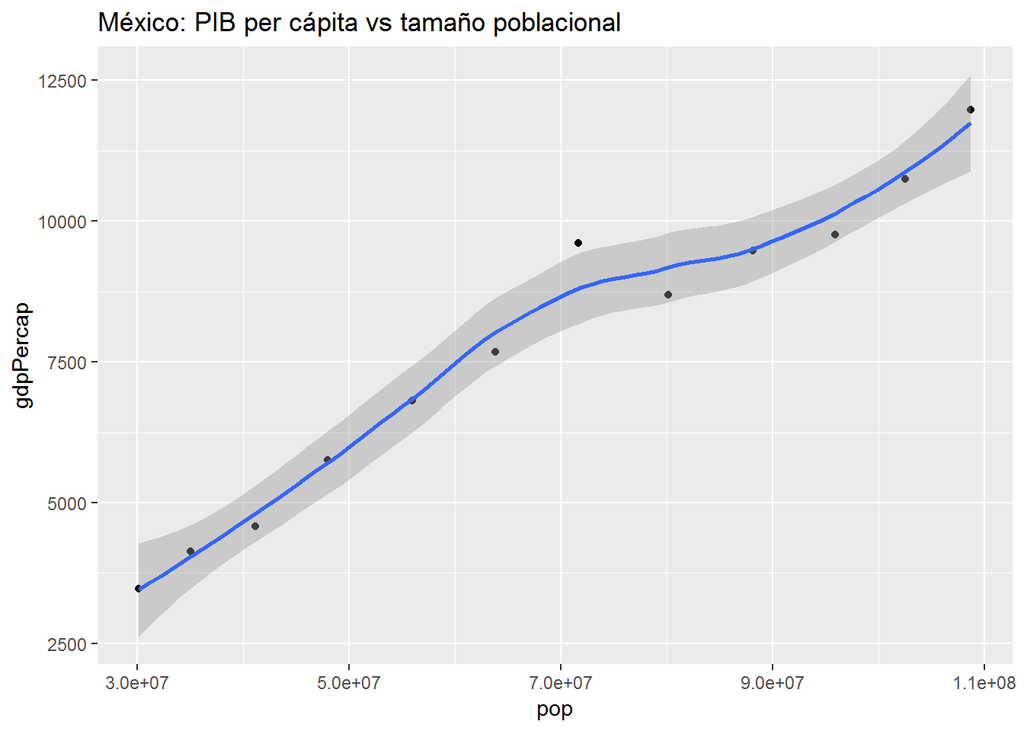

```r
Mexico <- gapminder %>% select(c(country, year, lifeExp, pop, gdpPercap)) %>% filter(country == 'Mexico')
ggplot(Mexico) + geom_point(aes(y=gdpPercap, x=pop), size=1.5) + ggtitle('México: PIB per cápita vs tamaño poblacional')  +
  geom_smooth(aes(y=gdpPercap, x=pop))
```

También pude notarse una asociación postiva entre estas variables.